# Supervised Learning - Foundations Project: ReCell

```python
olsmodel2 = sm.OLS(y_train, X_train3).fit()
print(olsmodel2.summary())
```

```
                                    OLS Regression Results
==============================================================================================
Dep. Variable:     normalized_used_price_log   R-squared (uncentered):                   0.998
Model:                                   OLS   Adj. R-squared (uncentered):              0.998
Method:                        Least Squares   F-statistic:                          1.123e+05
Date:                       Sun, 28 May 2023   Prob (F-statistic):                        0.00
Time:                               12:44:09   Log-Likelihood:                          3386.3
No. Observations:                       2417   AIC:                                     -6747.
Df Residuals:                           2404   BIC:                                     -6671.
Df Model:                                 13
Covariance Type:                   nonrobust
============================================================================================
                               coef    std err          t      P>|t|      [0.025      0.975]
--------------------------------------------------------------------------------------------
screen_size                  0.0069      0.001      8.796      0.000       0.005       0.008
main_camera_mp               0.0055      0.000     15.221      0.000       0.005       0.006
selfie_camera_mp             0.0030      0.000     12.778      0.000       0.003       0.004
ram                          0.0058      0.001      4.957      0.000       0.003       0.008
release_year              9.535e-05   1.79e-05      5.314      0.000    6.02e-05       0.000
normalized_new_price_log     0.5095      0.014     37.013      0.000       0.483       0.536
weight_log                   0.0447      0.008      5.428      0.000       0.029       0.061
brand_name_Celkon           -0.0680      0.013     -5.123      0.000      -0.094      -0.042
brand_name_Infinix           0.0564      0.027      2.093      0.036       0.004       0.109
brand_name_Nokia             0.0313      0.008      4.156      0.000       0.017       0.046
brand_name_Xiaomi            0.0182      0.006      2.817      0.005       0.006       0.031
os_Others                   -0.0311      0.007     -4.198      0.000      -0.046      -0.017
4g_yes                       0.0189      0.003      5.446      0.000       0.012       0.026
==============================================================================
Omnibus:                      872.251   Durbin-Watson:                   1.983
Prob(Omnibus):                  0.000   Jarque-Bera (JB):            12620.925
Skew:                          -1.299   Prob(JB):                         0.00
Kurtosis:                      13.889   Cond. No.                     4.47e+04
==============================================================================

Notes:
[1] R² is computed without centering (uncentered) since the model does not contain a constant.
[2] Standard Errors assume that the covariance matrix of the errors is correctly specified.
[3] The condition number is large, 4.47e+04. This might indicate that there are
strong multicollinearity or other numerical problems.
```

TEST FOR LINEARITY AND INDEPENDENCE We will test for linearity and independence by making a plot of fitted values vs residuals and checking for patterns. If there is no pattern, then we say the model is linear and residuals are independent. Otherwise, the model is showing signs of non-linearity and residuals are not independent.

```python
# let us create a dataframe with actual, fitted and residual values
df_pred = pd.DataFrame()

df_pred["Actual Values"] = y_train  # actual values
df_pred["Fitted Values"] = olsmodel2.fittedvalues  # predicted values
df_pred["Residuals"] = olsmodel2.resid  # residuals

df_pred.head()
```

|  | Actual Values | Fitted Values | Residuals |
| --- | --- | --- | --- |
| 1744 | 1.449733 | 1.461394 | -0.011661 |
| 3141 | 1.429152 | 1.341328 | 0.087823 |
| 1233 | 1.415224 | 1.488924 | -0.073699 |
| 3046 | 1.330411 | 1.351636 | -0.021225 |
| 2649 | 1.381765 | 1.372649 | 0.009115 |

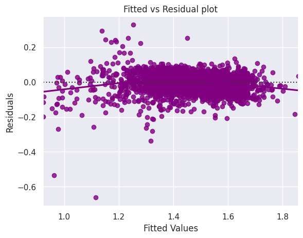

```python
# let's plot the fitted values vs residuals

sns.residplot(
    data=df_pred, x="Fitted Values", y="Residuals", color="purple", lowess=True
)
plt.xlabel("Fitted Values")
plt.ylabel("Residuals")
plt.title("Fitted vs Residual plot")
plt.show()
```

TEST FOR NORMALITY We will test for normality by checking the distribution of residuals, by checking the Q-Q plot of residuals, and by using the Shapiro-Wilk test. If the residuals follow a normal distribution, they will make a straight line plot, otherwise not. If the p-value of the Shapiro-Wilk test is greater than 0.05, we can say the residuals are normally distributed.

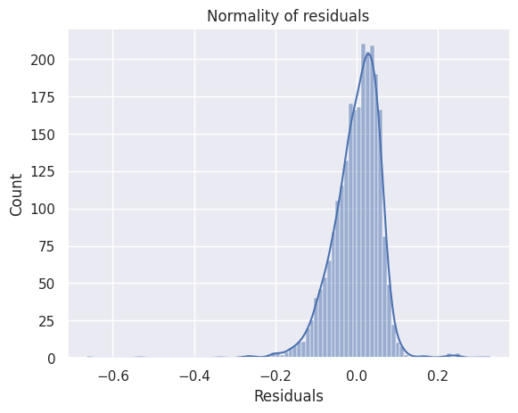

```python
sns.histplot(data=df_pred, x="Residuals", kde=True)
plt.title("Normality of residuals")
plt.show()
```

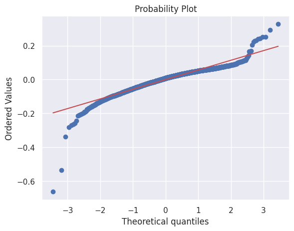

```python
import pylab
import scipy.stats as stats

stats.probplot(df_pred["Residuals"], dist="norm", plot=pylab)
plt.show()
```

```python
stats.shapiro(df_pred["Residuals"])
```

```
ShapiroResult(statistic=0.9147539734840393, pvalue=7.122119381484394e-35)
```

TEST FOR HOMOSCEDASTICITY We will test for homoscedasticity by using the goldfeldquandt test. If we get a p-value greater than 0.05, we can say that the residuals are homoscedastic. Otherwise, they are heteroscedastic.

```python
import statsmodels.stats.api as sms
from statsmodels.compat import lzip

name = ["F statistic", "p-value"]
test = sms.het_goldfeldquandt(df_pred["Residuals"], X_train3)
lzip(name, test)
```

```
[('F statistic', 0.8124805645454447), ('p-value', 0.9998321416466479)]
```

## Final Model

```python
olsmodel_final = sm.OLS(y_train, X_train3).fit()
print(olsmodel_final.summary())
```

```
                                    OLS Regression Results
==============================================================================================
Dep. Variable:     normalized_used_price_log   R-squared (uncentered):                   0.998
Model:                                   OLS   Adj. R-squared (uncentered):              0.998
Method:                        Least Squares   F-statistic:                          1.123e+05
Date:                       Sun, 28 May 2023   Prob (F-statistic):                        0.00
Time:                               12:45:06   Log-Likelihood:                          3386.3
No. Observations:                       2417   AIC:                                     -6747.
Df Residuals:                           2404   BIC:                                     -6671.
Df Model:                                 13
Covariance Type:                   nonrobust
============================================================================================
                               coef    std err          t      P>|t|      [0.025      0.975]
--------------------------------------------------------------------------------------------
screen_size                  0.0069      0.001      8.796      0.000       0.005       0.008
main_camera_mp               0.0055      0.000     15.221      0.000       0.005       0.006
selfie_camera_mp             0.0030      0.000     12.778      0.000       0.003       0.004
ram                          0.0058      0.001      4.957      0.000       0.003       0.008
release_year              9.535e-05   1.79e-05      5.314      0.000    6.02e-05       0.000
normalized_new_price_log     0.5095      0.014     37.013      0.000       0.483       0.536
weight_log                   0.0447      0.008      5.428      0.000       0.029       0.061
brand_name_Celkon           -0.0680      0.013     -5.123      0.000      -0.094      -0.042
brand_name_Infinix           0.0564      0.027      2.093      0.036       0.004       0.109
brand_name_Nokia             0.0313      0.008      4.156      0.000       0.017       0.046
brand_name_Xiaomi            0.0182      0.006      2.817      0.005       0.006       0.031
os_Others                   -0.0311      0.007     -4.198      0.000      -0.046      -0.017
4g_yes                       0.0189      0.003      5.446      0.000       0.012       0.026
==============================================================================
Omnibus:                      872.251   Durbin-Watson:                   1.983
Prob(Omnibus):                  0.000   Jarque-Bera (JB):            12620.925
Skew:                          -1.299   Prob(JB):                         0.00
Kurtosis:                      13.889   Cond. No.                     4.47e+04
==============================================================================

Notes:
[1] R² is computed without centering (uncentered) since the model does not contain a constant.
[2] Standard Errors assume that the covariance matrix of the errors is correctly specified.
[3] The condition number is large, 4.47e+04. This might indicate that there are
strong multicollinearity or other numerical problems.
```

## Actionable Insights and Recommendations

The used price of newly released phones tends to be higher, which is logical considering that newer phones have higher original prices. Consequently, the used price is influenced, with older phones generally having lower prices. This is because customers often prefer phones that are currently in demand.